# Statistical Inference Course Project

Jimmy

6/6/2020

### Statistical Inference Course Project s

### Part 1 - A Simulation Exercise

**Overview**

In this project we will investigate the exponential distribution in R and compare it with the Central Limit Theorem. The exponential distribution can be simulated in R with rexp(n, lambda) where lambda is the rate parameter. The mean of exponential distribution is 1/lambda and the standard deviation is also 1/lambda. We will set lambda = 0.2 for all of the simulations. We will investigate the distribution of averages of 40 exponentials. We will do a thousand simulations.

Setting a seed for reproducibility:

```r
set.seed(111)
```

Setting a rate parameter lambda:

```r
lambda = 0.2
```

Setting a size of a sample:

```r
n = 40
```

Setting a number of simulations:

```r
nosim = 1000
```

Generating 1000 samples of 40 exponentials and calculating their mean values:

```r
r <- replicate(nosim, rexp(n, lambda))
dim(r)
```

```
## [1]   40 1000
```

```r
class(r)
```

```
## [1] "matrix"
```

We can see that r is a matrix of 40 rows and 1000 columns. Since each column contains a sample of 40 random exponentials we’ll apply mean() to columns to get 1000 sample means.

```r
exp_means <- apply(r, 2, mean)
```

**1. Show the sample mean and compare it to the theoretical mean of the distribution.**

Sample(empirical) mean:

```r
e_mean <- mean(exp_means)
e_mean
```

```
## [1] 5.02562
```

Theoretical mean:

```r
t_mean<- 1/lambda
t_mean
```

```
## [1] 5
```

We can see that the sample mean 5.02562 is good approximation of the theoretical mean t_mean = 5.

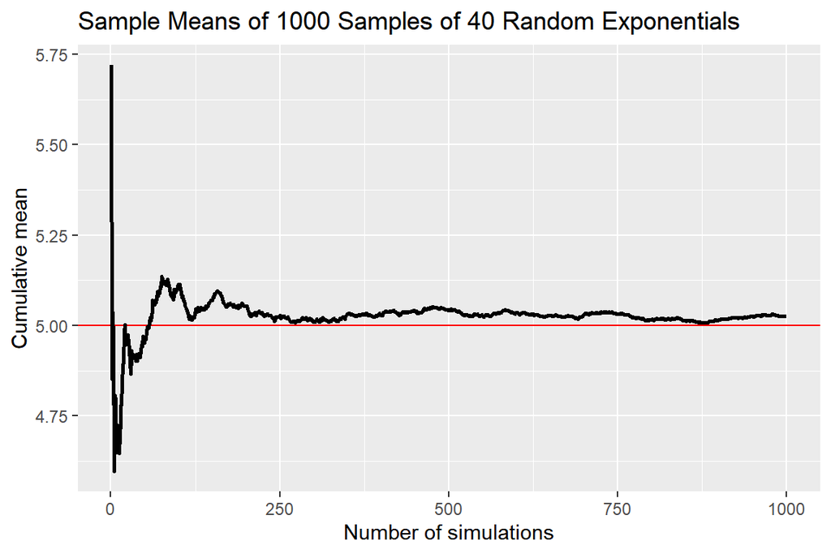

```r
means <- cumsum(exp_means)/(1:nosim)
library(ggplot2)
g <- ggplot(data.frame(x = 1:nosim, y = means), aes(x = x, y = y))
g <- g + geom_hline(yintercept = t_mean, colour = 'red') + geom_line(size = 1)
g <- g + labs(x = "Number of simulations", y = "Cumulative mean")
g <- g + ggtitle('Sample Means of 1000 Samples of 40 Random Exponentials ')
g
```

As we can see from the graph, empirical mean is a consistent estimator of theoretical mean, because it converges to the value of theoretical mean.

**2. Show how variable the sample is (via variance) and compare it to the theoretical variance of the distribution.**

Sample variance:

```r
e_var <- var(exp_means)
e_var
```

```
## [1] 0.6069798
```

Theoretical variance of the distribution of sample means:

```r
t_var <- (1/(lambda*sqrt(n)))^2
t_var
```

```
## [1] 0.625
```

As we can see, both empirical and theorietical variance of the distribution of sample means have value close to 0.6.

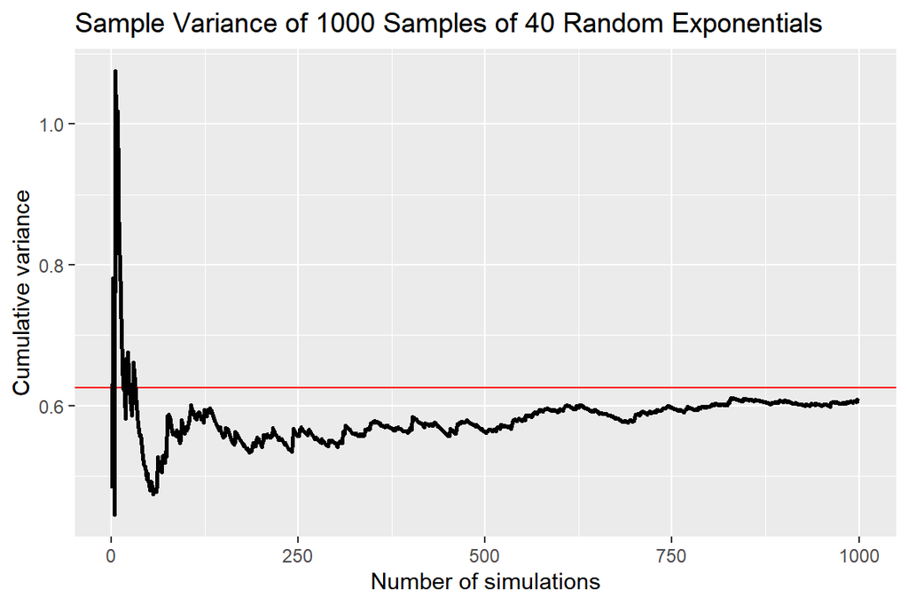

```r
cumvar <- cumsum((exp_means - e_mean)^2)/(seq_along(exp_means - 1))
g <- ggplot(data.frame(x = 1:nosim, y = cumvar), aes(x = x, y = y))
g <- g + geom_hline(yintercept = t_var, colour = 'red') + geom_line(size = 1)
g <- g + labs(x = "Number of simulations", y = "Cumulative variance")
g <- g + ggtitle('Sample Variance of 1000 Samples of 40 Random Exponentials ')
g
```

**3. Show that the distribution is approximately normal.**

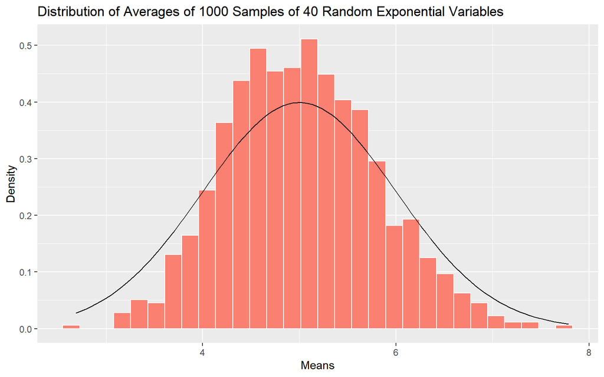

```r
g <- ggplot(data = data.frame(x = exp_means), aes(x = x))
g <- g + geom_histogram(aes(y = ..density..), colour = 'white', fill = 'salmon')
g <- g + stat_function(fun = dnorm, colour = 'black', args = list(mean = t_mean))
g <- g + ggtitle('Distribution of Averages of 1000 Samples of 40 Random Exponential Variables')
g <- g + xlab('Means')
g <- g + ylab('Density')
g
```

As we can see from the graph the distribution of averages of 1000 samples of 40 iid exponentials is approximately normal.